# Performance Analysis and Vehicle Characteristics in the “Dakar Desert Rally”

Leandro Fermino Uchôa

October / 2024

# Introduction

Hello, my name is Leandro Fermino Uchôa, and this document is part of my capstone project for the Google Data Analytics Professional Certificate, offered by Google through the Coursera platform [(course link)](https://www.coursera.org/professional-certificates/analise-de-dados-do-google). The goal of this project is to analyze the performance and characteristics of vehicles in the game “Dakar Desert Rally” [(official site)](https://www.dakarthegame.com/en/), using detailed data to identify which vehicles perform best and how these characteristics influence price and player choice.

## About the Game

“Dakar Desert Rally” is a racing game that simulates the famous Dakar rally, offering a realistic and challenging experience for players. The version of the game used for this analysis includes the base game and the DLC “Dakar Desert Rally - SnowRunner Cars Pack”.

## Project Objective

The objective of this project is to: - Identify which vehicles perform best in terms of speed, durability, and other characteristics. - Analyze how these characteristics influence price and player choice. - Provide insights that can help improve vehicle balancing in the game, inform decisions about updates and new releases, and develop more effective marketing strategies.

## Document Structure

This document is structured as follows: 1. **Guiding Questions**: Questions that guide the analysis. 2. **Main Tasks**: Tasks necessary to achieve the project’s objectives. 3. **Delivery**: Clear statement of the business task and the insights obtained. 4. **References**: Sources of data and information used in the project.

## Contact

- **Name**: Leandro Fermino Uchôa
- **LinkedIn**: [Leandro Fermino Uchôa](https://www.linkedin.com/in/lfuchoa/)

### Phase 1: Guiding Questions:

1. **What theme are you exploring?**
   - **Theme**: Performance and characteristics analysis of vehicles in the game “Dakar Desert Rally” [(official site)](https://www.dakarthegame.com/en/).
2. **What problem are you trying to solve?**
   - **Problem**: Identify which vehicles perform best in terms of speed, durability, and other characteristics, and how these characteristics influence price and player choice.
3. **What metrics will you use to measure your data to achieve your goal?**
   - **Metrics**:
     - Speed
     - Acceleration
     - Handling
     - Durability
     - Power (Power_hp)
     - Torque (Torque_Nm)
     - Top Speed (Top_Speed_km_h)
     - Price (Price_DP)
4. **Who are the stakeholders?**
   - **Stakeholders**:
     - Product managers
     - Game developers
     - Data analysts
     - Players
     - Marketing team
5. **Who is your target audience?**
   - **Target audience**:
     - Product managers
     - Game developers
     - Data analysts
     - Players
     - Other stakeholders interested in improving vehicle performance and experience in the game.
6. **How can your insights help your client make decisions?**
   - **Decision-making assistance**:
     - Improve vehicle balancing in the game.
     - Inform decisions about updates and new vehicle releases.
     - Optimize player experience.
     - Develop more effective marketing strategies.

#### Main Tasks:

1. **Identify the business task**:
   - **Business task**: Analyze the data of vehicles in the game “Dakar Desert Rally” to identify insights about performance, characteristics, and possible improvements.
2. **Determine the key stakeholders**:
   - **Key stakeholders**: Product managers, game developers, data analysts, players, marketing team.
3. **Choose a dataset**:
   - **Dataset**: Detailed dataset on vehicles in the game “Dakar Desert Rally” [(DDR_Vehicles_List_Stats)](https://docs.google.com/spreadsheets/d/1j0BqVWwg1OkH2lJUIPKKPCIlDCHA7fQ124iqvNppVgw/edit?usp=sharing), extracted from the Google Sheets link provided by the user “faminho” [(Steam profile)](https://steamcommunity.com/id/faminho) in a community post.
4. **Establish metrics**:
   - **Metrics**: Speed, acceleration, handling, durability, power, torque, top speed, price.

#### Delivery:

**Clear statement of the business task**: - **Business task**: Analyze the data of vehicles in the game “Dakar Desert Rally” to identify insights about performance, characteristics, and possible improvements. The goal is to understand which vehicles perform best and how their characteristics influence price and player choice, helping the company make informed decisions about balancing, updates, and marketing strategies.

### Phase 2: Data Preparation

#### 1. Where is your data located?

The data is located in a CSV file that was imported into RStudio. The file was originally checked and cleaned in Excel before being exported to RStudio.

#### 2. How is the data organized?

The data is organized in a wide format, where each row represents a vehicle and each column represents a specific attribute of that vehicle.

#### 3. Are there any issues with bias or credibility in this data? Is your data reliable, original, comprehensive, current, and does it include the source?

The data comes from the game [“Dakar Desert Rally”](https://www.dakarthegame.com/en/) released on 4/Oct/2022. So it is still comprehensive and current, especially considering the game universe itself. As for completeness and completeness, both have already been reviewed to ensure there is no bias.

#### 4. How are you handling licensing, privacy, security, and accessibility?

The data is from a game, so we are adhering to the game’s terms of use and licensing. There is no sensitive personal data, so privacy and security are less of a concern here.

#### 5. How did you verify data integrity?

Data integrity was ensured through a thorough check in Excel. In this process, I eliminated missing and duplicate values, removed unnecessary whitespace at the beginning and end of cells, and standardized column names for consistency. It is important to note that the ‘Price_DP’ field intentionally contains ‘NA’ values, aiming for more efficient analysis of the dataset. Here is the code used to check the integrity of the data in the R environment:

```r
# Check for missing values
sum(is.na(DDR_Vehicles_List_Stats_df))
```

```
## [1] 18
```

```r
# Check for duplicates
sum(duplicated(DDR_Vehicles_List_Stats_df))
```

```
## [1] 0
```

#### Deliverable:

**A description of all data sources used**: - **Sources Used**: The sources used include the game’s official website and the datasheet provided by the user ‘faminho’ on the game’s community page on the Steam platform.

#### References

- [Official website of the game “Dakar Desert Rally”](https://www.dakarthegame.com/en/)
- [Google Sheets - Original dataset](https://docs.google.com/spreadsheets/d/1j0BqVWwg1OkH2lJUIPKKPCIlDCHA7fQ124iqvNppVgw/edit?usp=sharing)
- [Steam profile of the user “faminho”](https://steamcommunity.com/id/faminho)
- [Post in the game’s community on Steam](https://steamcommunity.com/sharedfiles/filedetails/?id=2893717112)

### Phase 3: Process the Data

#### 1. What tools are you choosing and why?

I am using Excel for initial data cleaning and R with the `dplyr` and `tidyr` packages for data manipulation and verification. Excel is an intuitive and effective tool for data cleaning, while R is powerful for data manipulation and integrity checking.

#### 2. Have you ensured the integrity of your data?

Yes, data integrity was ensured through detailed checks in Excel, where I removed missing and duplicate values, and standardized column names. I then confirmed the integrity of the data in R.

#### 3. What steps were taken to ensure that your data is clean?

In Excel, I removed missing and duplicate values, eliminated unnecessary whitespace, and standardized column names. In R, I used functions to check for missing and duplicate values, and to ensure data consistency.

#### 4. How can you check if your data is clean and ready for analysis?

By checking for missing and duplicate values in R, and using summary functions to ensure that the data is consistent and ready for analysis.

#### 5. Did you document your cleaning process so that you can review and share the results?

Yes, the entire cleaning process was documented in Excel and committed to RMarkdown code, allowing you to review and share the results.

#### Deliverable:

Data Cleaning and Manipulation Documentation

#### Introduction

The purpose of this document is to describe the data cleaning and manipulation process for the game “Dakar Desert Rally”. Data cleaning was performed in Excel, and data integrity was confirmed in RStudio.

#### Tools Used

- **Excel**: Used for initial data cleaning.
- **RStudio**: Used to confirm data integrity.
- **R Packages**: `dplyr`, `tidyr`

#### Cleaning and Manipulation Steps

1. **Data Import**
- Data was imported into Excel from a Google Sheets spreadsheet.
2. **Missing Value Removal**
- Missing values were identified and removed to ensure data integrity.
3. **Removing Duplicates**
- Duplicate rows were removed to avoid redundancy.
4. **Eliminating Whitespace**
- Unnecessary whitespace at the beginning and end of cells was removed.
5. **Standardizing Column Names**
- Column names were standardized to ensure consistency.
6. **Exporting Data**
- The cleaned data was exported to a CSV file.
7. **Confirming the Cleansing in RStudio**
- The CSV file was imported into RStudio to confirm the data cleansing

### Phase 4: Analyze the Data

#### 1. Descriptive Summary of Key Measures of a Data Set:

In this descriptive summary, I present the key measures of a data set, including minimum, first quartile, median, mean, third quartile, and maximum:

- **Min. (Minimum)**: The smallest value in the data set.
- **1st Qu. (First Quartile)**: The value below which 25% of the data lies.
- **Median (Median)**: The central value that divides the data set into two equal halves.
- **Mean (Mean)**: The arithmetic mean of the values.
- **3rd Qu. (Third Quartile)**: The value below which 75% of the data lies.
- **Max. (Maximum)**: The largest value in the data set.

These values help to understand the distribution of the data, showing the central tendency and dispersion.

```r
# Statistical Summary:
summary(DDR_Vehicles_List_Stats_df)
```

```
##  Vehicle_Type         Category            Number             Driver
##  Length:277         Length:277         Length:277         Length:277
##  Class :character   Class :character   Class :character   Class :character
##  Mode  :character   Mode  :character   Mode  :character   Mode  :character
##
##
##
##
##  Drivers_Country       Brand              Model               Team
##  Length:277         Length:277         Length:277         Length:277
##  Class :character   Class :character   Class :character   Class :character
##  Mode  :character   Mode  :character   Mode  :character   Mode  :character
##
##
##
##
##    Team_Score         Speed         Acceleration       Handling
##  Min.   : 1.000   Min.   : 3.000   Min.   : 3.000   Min.   : 4.000
##  1st Qu.: 5.000   1st Qu.: 5.000   1st Qu.: 6.000   1st Qu.: 7.000
##  Median : 5.000   Median : 6.000   Median : 7.000   Median : 8.000
##  Mean   : 5.448   Mean   : 6.123   Mean   : 7.227   Mean   : 7.552
##  3rd Qu.: 6.000   3rd Qu.: 7.000   3rd Qu.: 8.000   3rd Qu.: 8.000
##  Max.   :10.000   Max.   :10.000   Max.   :10.000   Max.   :10.000
##
##    Durability      Drivetrain          Length_mm       Width_mm
##  Min.   : 1.000   Length:277         Min.   :1482   Min.   : 800
##  1st Qu.: 2.000   Class :character   1st Qu.:2191   1st Qu.:1171
##  Median : 5.000   Mode  :character   Median :3825   Median :1925
##  Mean   : 4.913                      Mean   :3817   Mean   :1726
##  3rd Qu.: 7.000                      3rd Qu.:4690   3rd Qu.:2200
##  Max.   :10.000                      Max.   :7100   Max.   :2550
##
##    Height_mm     Wheelbase_mm     Engine             Power_hp
##  Min.   : 960   Min.   :1280   Length:277         Min.   :  28.0
##  1st Qu.:1271   1st Qu.:1535   Class :character   1st Qu.:  68.0
##  Median :1740   Median :2591   Mode  :character   Median : 195.0
##  Mean   :1818   Mean   :2614                      Mean   : 341.1
##  3rd Qu.:1910   3rd Qu.:3060                      3rd Qu.: 375.0
##  Max.   :3550   Max.   :4300                      Max.   :1250.0
##
##    Torque_Nm      Top_Speed_km_h     Price_DP       Source
##  Min.   :  45.0   Min.   :154.0   Min.   : 110   Length:277
##  1st Qu.:  47.7   1st Qu.:178.0   1st Qu.: 655   Class :character
##  Median : 200.0   Median :194.0   Median :1400   Mode  :character
##  Mean   : 918.5   Mean   :191.6   Mean   :1965
##  3rd Qu.: 700.0   3rd Qu.:203.0   3rd Qu.:2700
##  Max.   :5000.0   Max.   :225.0   Max.   :9999
##                                   NA's   :18
##  Full_Stats_No_TS Full_Stats_With_TS
##  Min.   :15.00    Min.   :20.00
##  1st Qu.:23.00    1st Qu.:28.00
##  Median :26.00    Median :31.00
##  Mean   :25.82    Mean   :31.26
##  3rd Qu.:28.00    3rd Qu.:34.00
##  Max.   :31.00    Max.   :40.00
##
```

#### 2. List of the Best Vehicles by Category:

One of the factors that led me to work on this dataset is my passion for racing games, especially as a player of this particular game. As a player, one of the questions I always ask myself, and I know other players ask me too, is: “What is the best car?”

With that in mind, I had no doubts: this was the big question I wanted to answer. Here is the answer.

```r
datatable(best_vehicles_per_vehicle_type, options = list(
  autoWidth = TRUE,
  scrollX = TRUE,
  scrollY = "400px",  # Adjust the height as needed
  paging = FALSE  # Disables pagination to show all rows
))
```

|  | Vehicle_Type | Category | Number | Driver | Drivers_Country | Brand | Model | Team | Full_Stats_No_TS | Handling | Acceleration | Speed | Durability | Price_DP |
| --- | --- | --- | --- | --- | --- | --- | --- | --- | --- | --- | --- | --- | --- | --- |
| 1 | Bikes | Dakar 22 | 1 | Kevin Benavides | Argentina | KTM | 450 Rally Factory Replica | Red Bull KTM Factory Racing | 29 | 8 | 9 | 8 | 4 | 2700 |
| 2 | Bikes | Dakar 22 | 52 | Mathias Walkner | Austria | KTM | 450 Rally Factory Replica | Red Bull KTM Factory Racing | 29 | 8 | 9 | 8 | 4 | 3300 |
| 3 | Bikes | Dakar 22 | 18 | Toby Price | Australia | KTM | 450 Rally Factory Replica | Red Bull KTM Factory Racing | 29 | 8 | 9 | 8 | 4 | 4000 |
| 4 | Cars | Dakar 22 | 209 | Martin Prokop | Czech Republic | Ford | Raptor Cross Country RS T1+ | Benzina Orlen Team | 31 | 9 | 8 | 7 | 7 | 4200 |
| 5 | Quads | Dakar 20 | 250 | Ignacio Casale | Chile | Yamaha | Raptor 700 | Casale Racing | 19 | 6 | 8 | 3 | 2 | 1500 |
| 6 | SxS | Dakar 20 | 418 | Graham Knight | United Kingdom | Polaris | RZR 1000 Turbo | XtremePlus Polaris Factory Team | 23 | 9 | 6 | 4 | 4 | 1000 |
| 7 | SxS | Dakar 20 | 406 | Jose Luis Pena Campo | Spain | Polaris | RZR 1000 Turbo | XtremePlus Polaris Factory Team | 23 | 9 | 6 | 4 | 4 | 1500 |
| 8 | SxS | Dakar 20 | 424 | Eric Abel | France | Polaris | RZR 1000 Turbo | XtremePlus Polaris Factory Team | 23 | 9 | 6 | 4 | 4 | 1500 |
| 9 | SxS | Dakar 22 | 423 | Michelle Cinotto | Italy | Polaris | RZR PRO XP | XtremePlus Polaris Factory Team | 23 | 9 | 6 | 4 | 4 | 2400 |
| 10 | SxS | Dakar 22 | 437 | Pietro Cinotto | Italy | Polaris | RZR PRO XP | XtremePlus Polaris Factory Team | 23 | 9 | 6 | 4 | 4 | 2700 |

[output cut: 4 more lines]

#### 3. Vehicle Type Proportion Analysis:

In this analysis, we present a visual representation that illustrates the proportion of different vehicle types (`Vehicle_Type`) in the game as a whole. Each “slice” of the graph represents a vehicle type (`Vehicle_Type`), and its size is proportional to the percentage of that category in relation to the total.

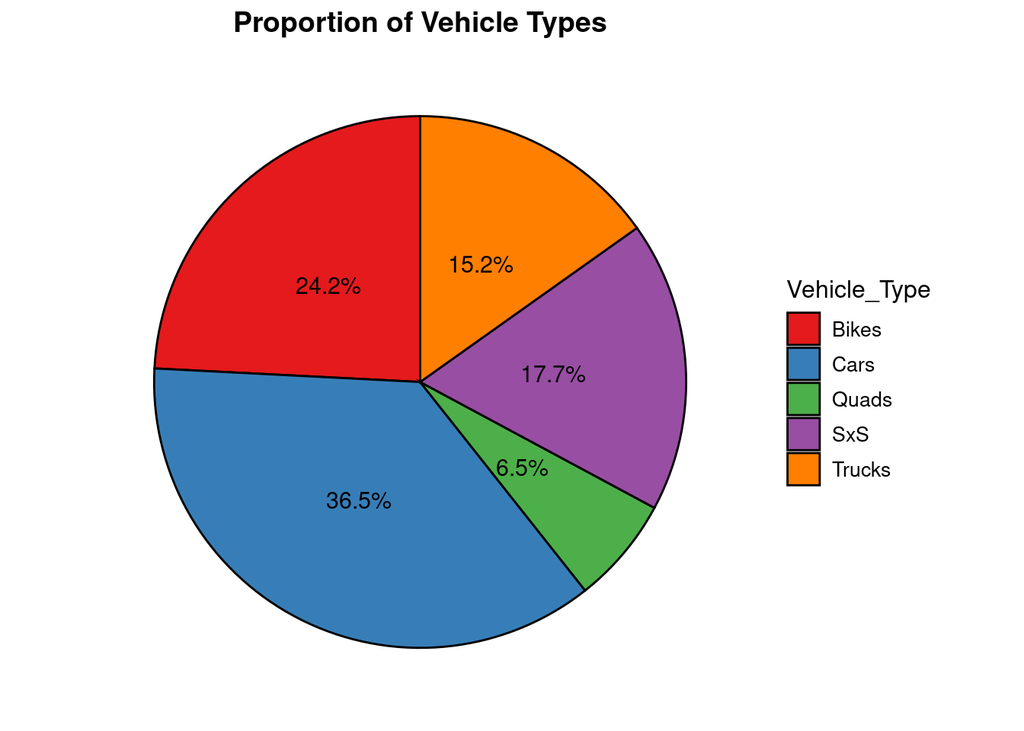

```r
# Create the total_vehicles_type dataframe from the DDR_Vehicles_List_Stats_df
total_veiculos_tipo <- DDR_Vehicles_List_Stats_df %>%
  group_by(Vehicle_Type) %>%
  summarise(n = n()) %>%
  mutate(percentage = (n / sum(n)) * 100)

# Pie chart showing the contribution of vehicle types to the total
ggplot(total_veiculos_tipo, aes(x = "", y = n, fill = Vehicle_Type)) +
  geom_bar(width = 1, stat = "identity", color = "black") +
  coord_polar("y", start = 0) +
  scale_fill_brewer(palette = "Set1") +
  geom_text(aes(label = paste0(round(percentage, 1), "%")),
            position = position_stack(vjust = 0.5), size = 4) +
  ggtitle("Proportion of Vehicle Types") +
  theme_minimal() +
  theme(
    plot.title = element_text(hjust = 0.5, size = 14, face = "bold"),
    axis.title = element_blank(),
    axis.text = element_blank(),
    axis.ticks = element_blank(),
    panel.grid = element_blank(),
    legend.title = element_text(size = 12),
    legend.text = element_text(size = 10)
  )
```

#### 4. Histogram Analysis of Price Distribution by Vehicle Type:

This histogram shows the price distribution (DP) by vehicle type (Vehicle_Type). The bars represent the frequency of vehicles in different price ranges, with distinct colors for each vehicle type. The bar width is set to 500 price units, and the chart uses the “Set1” color palette to differentiate vehicle types.

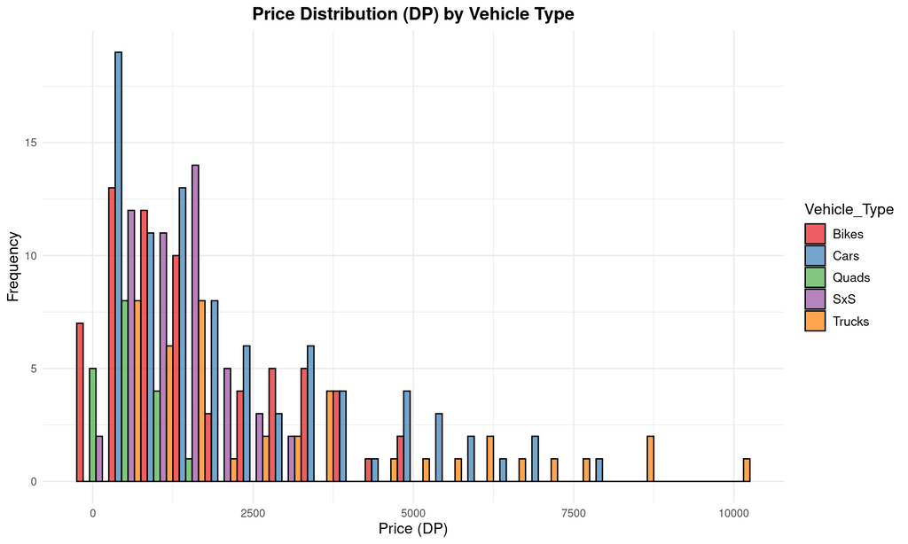

```r
# Filter records with N/A values in Price_DP
filtered_data <- DDR_Vehicles_List_Stats_df[!is.na(DDR_Vehicles_List_Stats_df$Price_DP), ]

# Histogram of Price Distribution by Vehicle Type
ggplot(data = filtered_data, aes(x = Price_DP, fill = Vehicle_Type)) +
  geom_histogram(binwidth = 500, color = "black", alpha = 0.7, position = "dodge") +
  scale_fill_brewer(palette = "Set1") +
  ggtitle("Price Distribution (DP) by Vehicle Type") +
  xlab("Price (DP)") +
  ylab("Frequency") +
  theme_minimal() +
  theme(
    plot.title = element_text(hjust = 0.5, size = 14, face = "bold"),
    axis.title = element_text(size = 12),
    legend.title = element_text(size = 12),
    legend.text = element_text(size = 10)
  )
```

#### 5. Scatterplot Analysis of the Relationship between Price and Team Score by Vehicle Type:

This scatterplot illustrates the relationship between the price (DP) and the Team Score of the vehicles in the database. Each point on the graph represents a vehicle, with the shape and color indicating the vehicle type. Through this graph, we can observe how different types of vehicles are distributed in terms of price and performance, allowing a visual analysis of the trends and patterns present in the data.

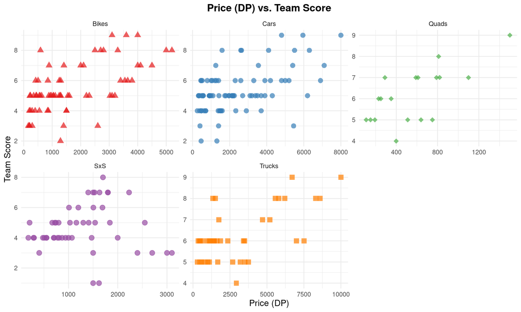

```r
# Filter records with N/A values in Price_DP
filtered_data <- DDR_Vehicles_List_Stats_df[!is.na(DDR_Vehicles_List_Stats_df$Price_DP), ]

# Code common to all graphs in the sequence
# Define the shapes for each type of vehicle
shapes <- c("Cars" = 16, "Trucks" = 15, "Bikes" = 17, "Quads" = 18, "SxS" = 19)  # 16: ball, 15: square, 17: triangle, 18: rhombus, 19: filled circle

# Scatterplot for Price vs. Team Score
ggplot(data = filtered_data, aes(x = Price_DP, y = Team_Score, shape = Vehicle_Type, color = Vehicle_Type)) +
  geom_point(size = 3, alpha = 0.7) +
  scale_shape_manual(values = shapes) +
  scale_color_brewer(palette = "Set1") +
  ggtitle("Price (DP) vs. Team Score") +
  xlab("Price (DP)") +
  ylab("Team Score") +
  theme_minimal() +
  theme(
    plot.title = element_text(hjust = 0.5, size = 14, face = "bold"),
    axis.title = element_text(size = 12),
    legend.position = "none"
  )+
  facet_wrap(~ Vehicle_Type, scales = "free")
```

#### 6. Correlation Analysis of Vehicle Attributes:

The graph below shows the correlation matrix for vehicle attributes, generated from the numeric columns of the DDR_Vehicles_List_Stats_df dataset. Using the ggcorrplot function, the colored circles indicate the strength and direction of the correlations: blue for positive correlations and red for negative correlations. The intensity of the color and the size of the circles reflect the magnitude of the correlation.

This graph helps identify meaningful relationships between vehicle attributes, aiding in informed analysis and decision-making.

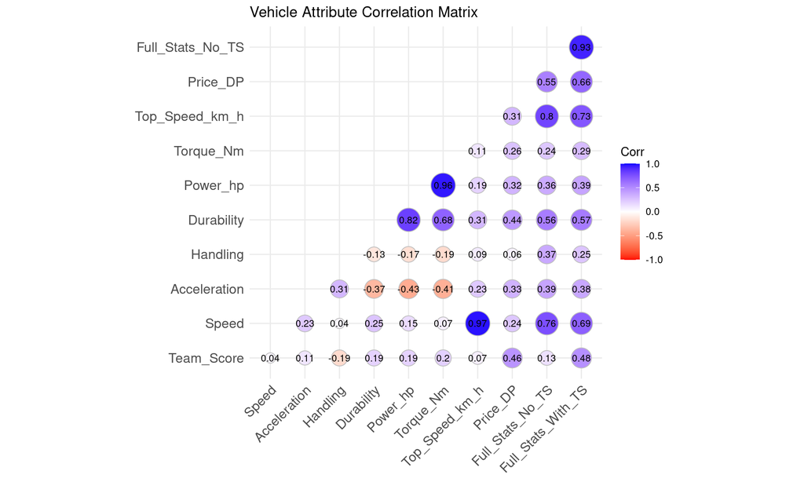

```r
# Code Explanation
# select(...): Selects only the numeric columns relevant to the correlation.
# cor(numerical_columns, use = "complete.obs"): Calculates the correlation matrix, ignoring missing values.
# ggcorrplot(...): Plots the correlation matrix with colored circles, where the size and color of the circles indicate the strength and direction of the correlation.
# Interpretation
# Colors: Blue indicates positive correlation, red indicates negative correlation, and white indicates little or no correlation.
# Circle Size: Larger circles indicate stronger correlations.

# Select only numeric columns for correlation
numerical_columns <- DDR_Vehicles_List_Stats_df %>%
  select(Team_Score, Speed, Acceleration, Handling, Durability, Power_hp, Torque_Nm, Top_Speed_km_h, Price_DP, Full_Stats_No_TS, Full_Stats_With_TS)

# Calculate the correlation matrix
cor_matrix <- cor(numerical_columns, use = "complete.obs")

# Plot the correlation matrix
ggcorrplot(cor_matrix,
           method = "circle",
           type = "lower",
           lab = TRUE,
           lab_size = 3,
           colors = c("red", "white", "blue"),
           title = "Vehicle Attribute Correlation Matrix",
           ggtheme = theme_minimal())
```

#### 7. Price Distribution by Vehicle Type:

The graph below shows a boxplot comparing the distribution of prices (SD) by vehicle type in the DDR_Vehicles_List_Stats_df dataset. Using the ggplot2 function, each boxplot represents the variation in prices within each vehicle category, highlighting the median, quartiles, and possible outliers. The colors were applied using the “Set1” palette for easy visualization.

This graph is useful for identifying differences and patterns in the prices of different vehicle types.

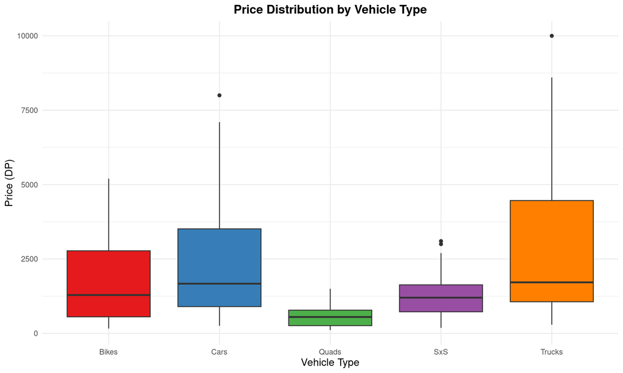

```r
# Filter records with N/A values in Price_DP
filtered_data <- DDR_Vehicles_List_Stats_df[!is.na(DDR_Vehicles_List_Stats_df$Price_DP), ]

# Boxplot to compare price distribution by vehicle type
ggplot(data = filtered_data, aes(x = Vehicle_Type, y = Price_DP, fill = Vehicle_Type)) +
  geom_boxplot() +
  scale_fill_brewer(palette = "Set1") +
  ggtitle("Price Distribution by Vehicle Type") +
  xlab("Vehicle Type") +
  ylab("Price (DP)") +
  theme_minimal() +
  theme(
    plot.title = element_text(hjust = 0.5, size = 14, face = "bold"),
    axis.title = element_text(size = 12),
    legend.position = "none"
  )
```

#### 8. Vehicle Types by Driver Nationality:

The graph below shows the distribution of vehicle types by driver nationality in the DDR_Vehicles_List_Stats_df dataset. Using the ggplot2 function, each bar represents the number of vehicles of each type, grouped by driver nationality. The colors were applied using the “Set1” palette for ease of visualization.

This graph is useful for identifying the diversity of vehicle types used by drivers of different nationalities.

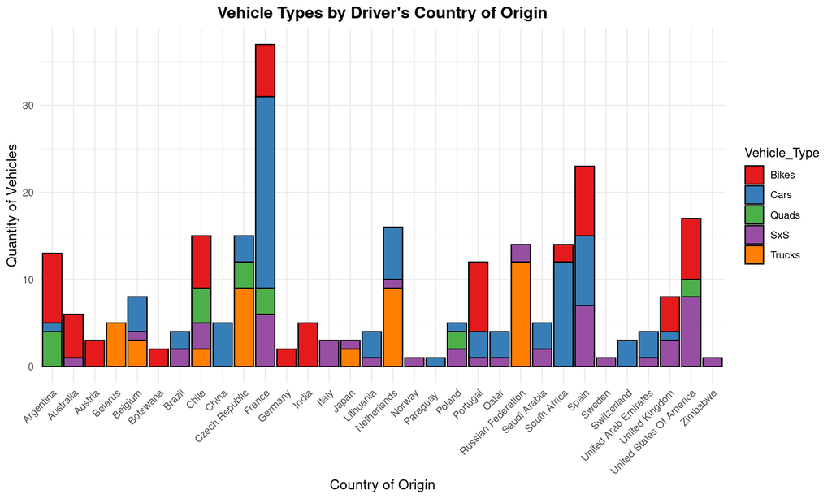

```r
# Filter records with N/A values in Price_DP
filtered_data <- DDR_Vehicles_List_Stats_df[!is.na(DDR_Vehicles_List_Stats_df$Price_DP), ]

# Stacked bar chart for vehicle types by driver country of origin
ggplot(data = filtered_data, aes(x = Drivers_Country, fill = Vehicle_Type)) +
  geom_bar(position = "stack", color = "black") +
  scale_fill_brewer(palette = "Set1") +
  ggtitle("Vehicle Types by Driver's Country of Origin") +
  xlab("Country of Origin") +
  ylab("Quantity of Vehicles") +
  theme_minimal() +
  theme(
    plot.title = element_text(hjust = 0.5, size = 14, face = "bold"),
    axis.title = element_text(size = 12),
    axis.text.x = element_text(angle = 45, hjust = 1)
  )
```

### Phase 6: Act

#### Conclusion:

Once the visualizations have been created and several insights have been generated from them, it is time to conclude the study.

The insights gained from this analysis can help players and developers better understand the characteristics and performance of vehicles in the “Dakar Desert Rally” game. Identifying trends and relationships between vehicle attributes can inform strategic decisions, such as choosing the best vehicle for different racing conditions. In addition, analyzing the diversity of drivers and the types of vehicles used can contribute to better balance and diversity in the game.

Another interesting point observed, frequently mentioned by the gaming community, is the importance of the “Team Score”. When analyzing this parameter, it initially does not seem to have a significant impact on the car’s performance. However, I believe that a new study focused on this premise is necessary to confirm this observation.

I would like to take this moment to express my gratitude to everyone who supported me throughout this course. It was a significant challenge, but with dedication and help, I was able to complete this project. I thank my teachers, colleagues and family for their continued support and encouragement. This work is a reflection of the collective effort and the learning acquired during this period.